# Assignment 7: Visualization - Some aspects of ggplot2

*How to do it?*:

- Open the Rmarkdown file of this assignment (link) in Rstudio.
- Right under each **question**, insert a code chunk (you can use the hotkey `Ctrl + Alt + I` to add a code chunk) and code the solution for the question.
- `Knit` the rmarkdown file (hotkey: `Ctrl + Alt + K`) to export an html.
- Publish the html file to your Githiub Page.

*Submission*: Submit the link on Github of the assignment to Blackboard.

**Questions**

Use the data of your own. Produce the following types of plots and comment on each plot. Plots should be meaningful. If you use the data we used in class, make sure the plots are not the same as the ones in the slides. All plots should have title, caption, appropriate labels on x and y-axis.

```r
library(tidyverse)
titanic_df=read_csv('train.csv')
```

1. Make a plot use `face_wrap` by one categorical variable (`face_wrap(~variable1)`)

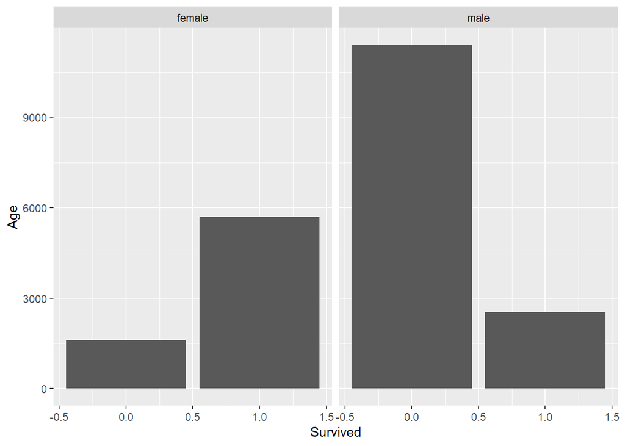

```r
library(ggplot2)

ggplot(titanic_df,aes(x=Survived,y=Age))+geom_col()+facet_wrap(~Sex)
```

2. Make a plot use `face_wrap` by two categorical variables (`face_wrap(variable1~variable2)`)

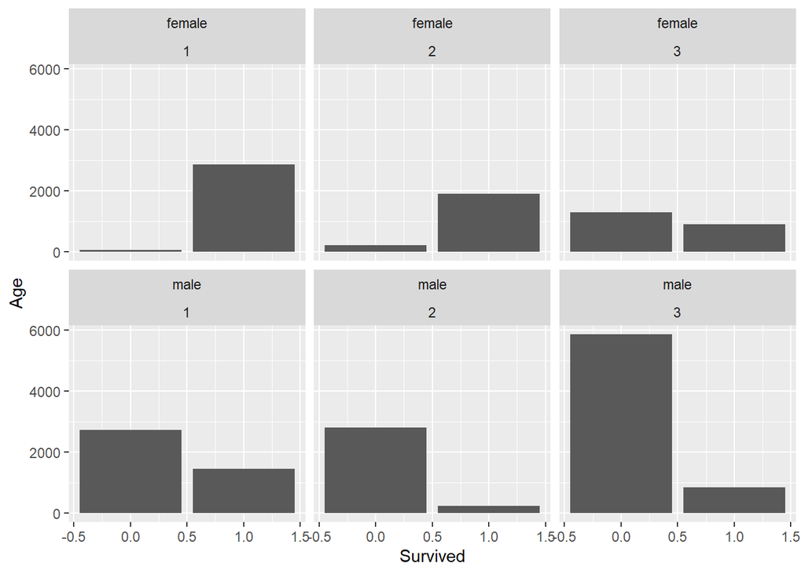

```r
ggplot(titanic_df,aes(x=Survived,y=Age))+geom_col()+facet_wrap(Sex~Pclass)
```

[figure not shown]

```r
ggplot(titanic_df, aes(x=Fare,y=Sex))+geom_point()
```

```r
position='jitter'
```

[figure not shown]

```r
ggplot(titanic_df,aes(x=Survived,fill=Age))+geom_bar()
```

```r
position='dodge'
```

[figure not shown]

```r
ggplot(titanic_df,aes(x=Survived,fill=Age))+geom_bar()
```

```r
position='fill'
```

6. Make a plot use `geom_col`.

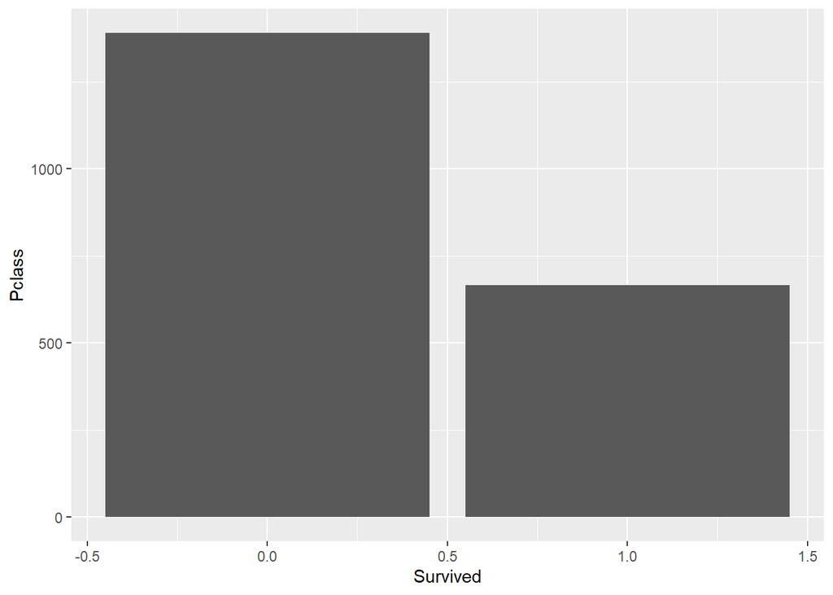

```r
ggplot(titanic_df,aes(x=Survived,y=Pclass))+geom_col()
```

[figure not shown]

```r
ggplot(titanic_df,aes(x=Survived,y=Pclass))+geom_col()
```

```r
theme_dark()
```

8. Save a plot and put a link of the plot to your Github Webpage. To link a plot `abc.png` you just need to insert the following on the README.md

```r
[Link to the plot](abc.png)
```